# Nationally Competitive Scholarships: What are the Odds?

Tyler Shimko (tyler@tylershimko.com)

July 9, 2014

All of the data used in this analysis were collected from publicly available sources including press releases and published statistics. The raw data are available at https://github.com/TShimko126/ScholarshipAnalysis.

## Undergraduate Scholarships

### The Udall Scholarship

This scholarship provides a one-time $5,000 scholarship for undergraduate study to students interested in environmental studies (including policy and sciences), tribal health care, or tribal policy. The Udall Foundation now awards 50 of the scholarships each year, with an additional 50 applicants receiving honorable mentions.

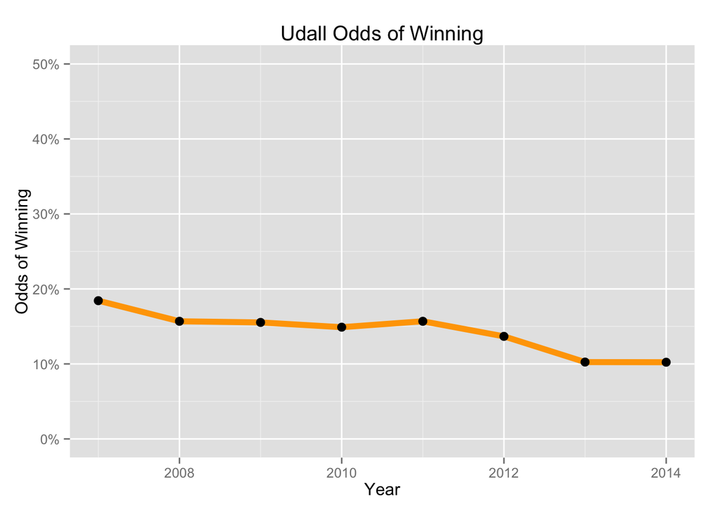

| Year | TotalApplicants | TotalWinners |
| --- | --- | --- |
| 2014 | 489 | 50 |
| 2013 | 488 | 50 |
| 2012 | 585 | 80 |
| 2011 | 510 | 80 |
| 2010 | 537 | 80 |
| 2009 | 515 | 80 |
| 2008 | 510 | 80 |
| 2007 | 434 | 80 |

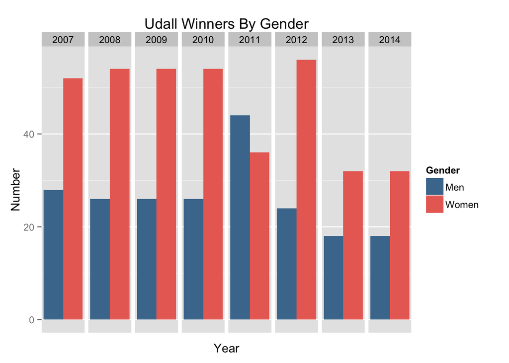

The foundation awards scholarships in three areas of interest: environmental studies, tribal health care, and tribal policy. The odds of winning the scholarship in any of these categories is shown in the graph below. Despite fewer overall scholarships being awarded in the categories of tribal health care and tribal policy, applicants in these disciplines are more likely to win, due to the lower numbers of applicants.

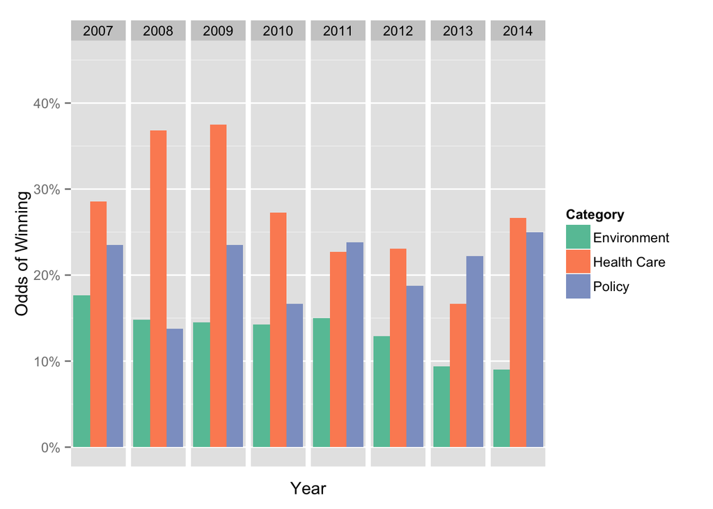

### The Goldwater Scholarship

This scholarship provides $7,500 for either one or two years of financial support, depending on whether the scholarship is won as a sophomore or a junior, respectively. This scholarship has a heavy focus on individuals in the sciences, specifically those looking to pursue a career in research.

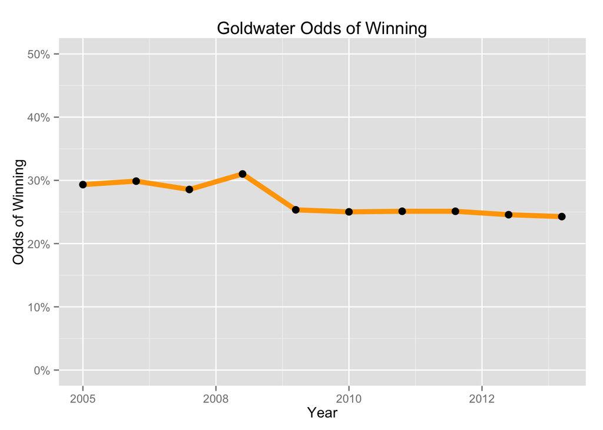

| Year | TotalApplicants | TotalWinners |
| --- | --- | --- |
| 2014 | 1166 | 283 |
| 2013 | 1107 | 272 |
| 2012 | 1123 | 282 |
| 2011 | 1095 | 275 |
| 2010 | 1111 | 278 |
| 2009 | 1097 | 278 |
| 2008 | 1035 | 321 |
| 2007 | 1110 | 317 |
| 2006 | 1081 | 323 |
| 2005 | 1091 | 320 |

Unlike the Udall scholarship, the Goldwater consistently awards more scholarships to males than to females.

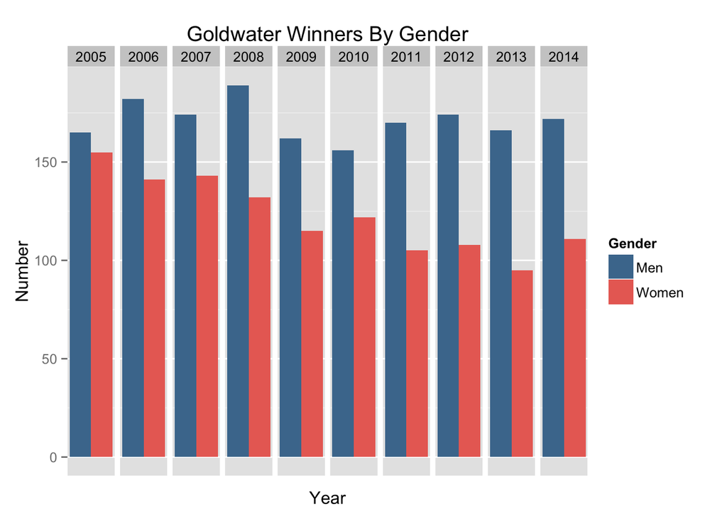

The overwhelming majority of the scholarships are awarded to students in the physical and life sciences, though in recent years engineering students have come to represent a growing proportion.

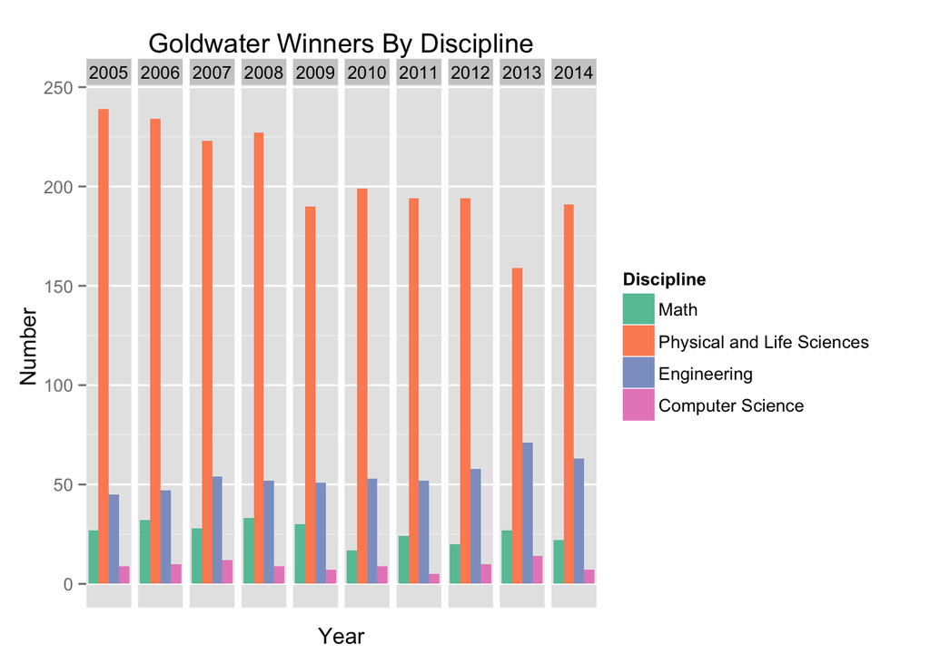

## Graduate Scholarships

### The Marshall Scholarship

**Note:** *The Marshall scholarships provides a rich data set in PDF format at http://www.marshallscholarship.org/about/statistics*

The Marshall Scholarship funds 1-2 years of study at many UK universities. The Marshall Scholarship is far more competitive than either of the undergraduate scholarships. The odds of winning a Marshall Scholarship consistently hover around 4%.

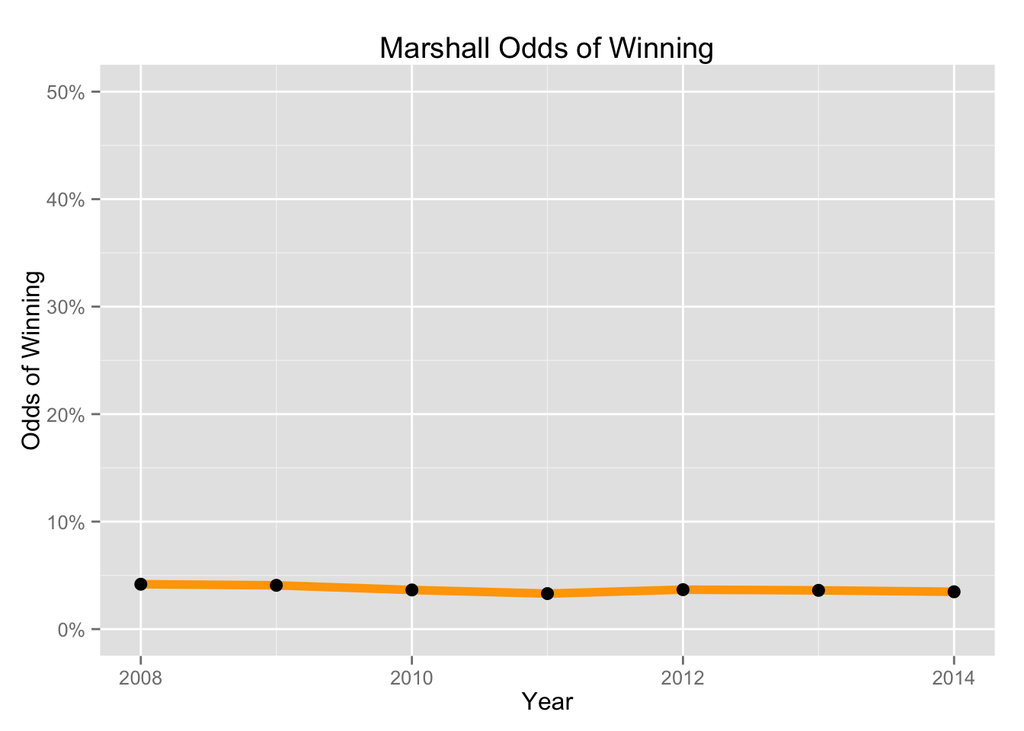

The Marshall Scholarship selection process includes three stages: endorsement by home university, interview, and selection. Given that the Marshall scholarship is rather open with their data, we can break down the flow of applicants through each of these stages.

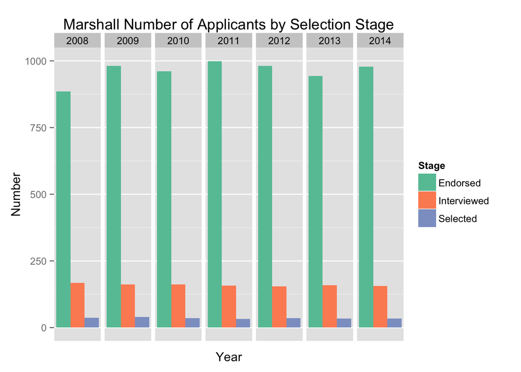

| Year | Stage1 | Stage2 |
| --- | --- | --- |
| 2014 | 0.1593 | 0.2179 |
| 2013 | 0.1686 | 0.2138 |
| 2012 | 0.1570 | 0.2338 |
| 2011 | 0.1582 | 0.2089 |
| 2010 | 0.1686 | 0.2160 |
| 2009 | 0.1650 | 0.2469 |
| 2008 | 0.1896 | 0.2202 |

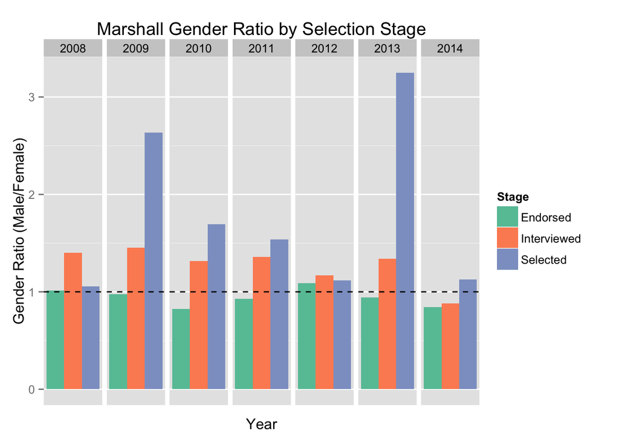

### The Rhodes Scholarship

The Rhodes Scholarship funds one postgraduate degree at the University of Oxford in the UK. Like the Marshall, the Rhodes is extremely competitive, with the odds of winning hovering around 4%.

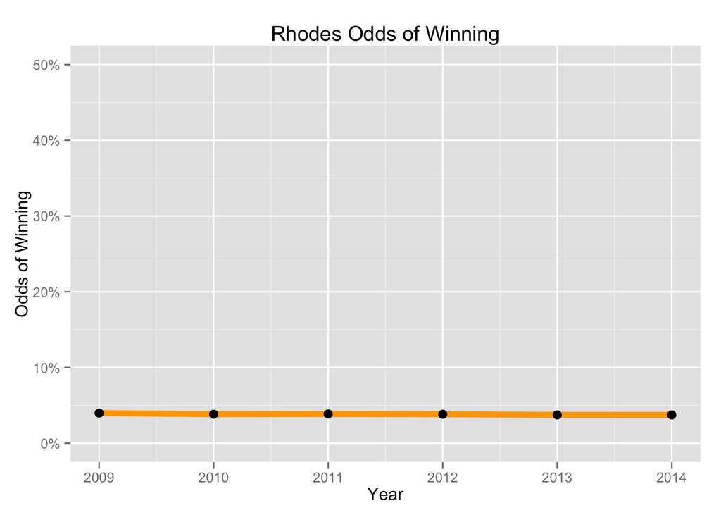

Unlike the Marshall, applicants’ chances of advancing from endorsement to interview are better than from interview to selection.

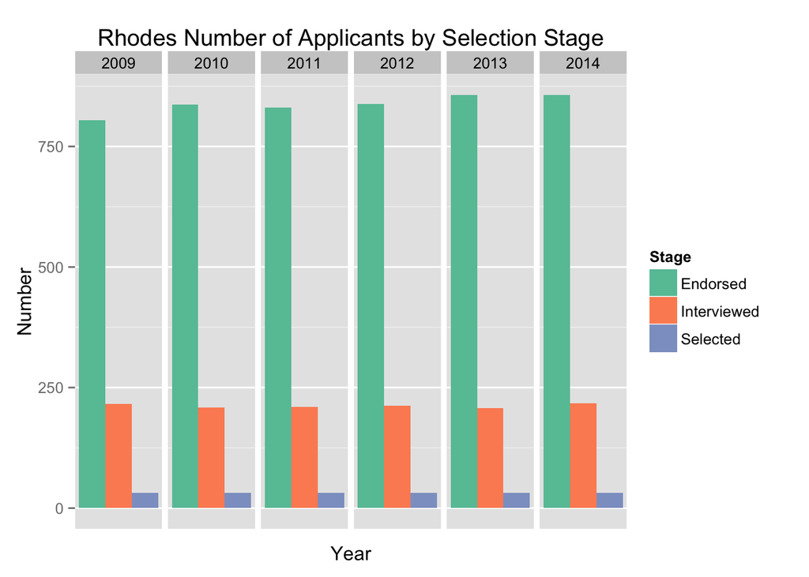

| Year | Stage1 | Stage2 |
| --- | --- | --- |
| 2014 | 0.2544 | 0.1468 |
| 2013 | 0.2427 | 0.1538 |
| 2012 | 0.2530 | 0.1509 |
| 2011 | 0.2530 | 0.1524 |
| 2010 | 0.2497 | 0.1531 |
| 2009 | 0.2683 | 0.1481 |

The Rhodes does not show a consistent skew toward one sex or the other in the past six years.

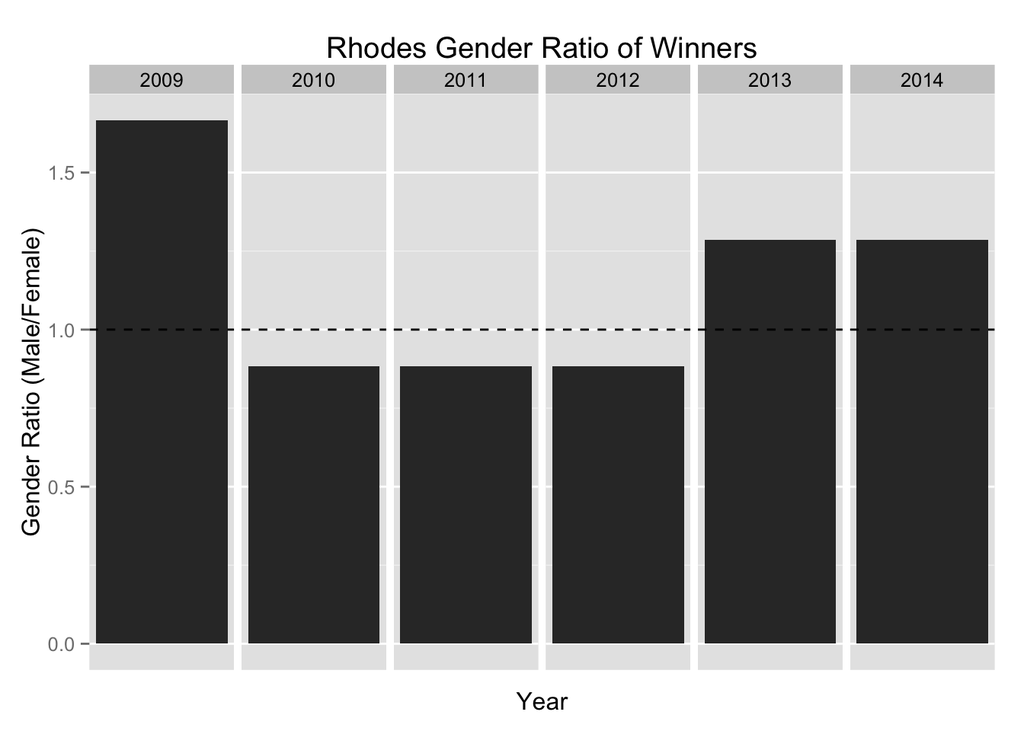

## Closing Remarks

This analysis is a work in progress. Its main purpose is to give prospective applicants an idea of the competitiveness of these scholarships and what their raw odds are for winning one of them. Check out the raw data if you would like to do your own analysis.